# SG1022 Seminar 2: Composite Indicators

2016

## Objectives

- Getting data into R from the World Bank Development Indicators with `WDI`
- Dealing with missing data
- Correlation (statistics and plots)
- Rescaling (with functions)
- Weighting and Aggregating

## Pop Quiz

- What is the **difference** between R and RStudio?
- In R, what are **packages** and how do you **install** and load them?
- What are **objects** and what are **functions**? Give examples.
- What is the **assignment operator**? What is **component selection**?

## World Development Indicators

You can also load data stored **remotely** (on another computer) into R. There are many ways to do this, depending on the data source.

Today we will download data from the World Bank's [World Development Indicators](http://data.worldbank.org/indicator) using the WDI package.

## Install packages.

Remember that to install a package use the `install.packages` function. **You only need to do this once.**

Today we will use six new packages that you need to install:

```r
# Create a vector of the packages to install
packages <- c('WDI', 'dplyr', 'DataCombine'
             'corrplot', 'googleVis', 'ggplot2')

# Install packages
install.packages(packages)
```

## Loading packages

**Each time you start R** and want to use functions from a package, you need to load the package with the `library` function. So, for today use:

```r
library(WDI)
library(dplyr)
library(DataCombine)
library(corrplot)
library(googleVis)
library(ggplot2)
```

Remember to **include this code at the top** of your source code file to ensure that it runs correctly.

## Find WDI Indicator ID

- **Go** the the World Bank's website: http://data.worldbank.org/indicator.
- **Click** on the indicator you are interested in.
- **Copy** the indicator ID. Example for *Methane Emissions*:

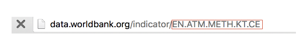

## Download WDI (1 indicator)

Now use the `WDI` function from the WDI package to download the indicator:

```r
# Download data. Place in new object called methane emissions
methane <- WDI(indicator = 'EN.ATM.METH.KT.CE', start = 1990,
                end = 2014)

head(methane)
```

```
##   iso2c    country EN.ATM.METH.KT.CE year
## 1    1A Arab World                NA 2014
## 2    1A Arab World                NA 2013
## 3    1A Arab World                NA 2012
## 4    1A Arab World                NA 2011
## 5    1A Arab World            437574 2010
## 6    1A Arab World                NA 2009
```

## Download WDI (multiple indicators)

We can download multiple indicators at once. To do this simply create a **vector of ID code strings**.

Let's download the following 5 indicators related to environmental sustainability:

```r
indicators <- c('EN.ATM.METH.KT.CE', 'EG.USE.ELEC.KH.PC',
                'EN.ATM.CO2E.PC', 'SP.POP.GROW',
                'EG.USE.COMM.CL.ZS')

wdi <- WDI(indicator = indicators, start = 1990, end = 2014)

names(wdi)
```

```
## [1] "iso2c"             "country"           "year"
## [4] "EN.ATM.METH.KT.CE" "EG.USE.ELEC.KH.PC" "EN.ATM.CO2E.PC"
## [7] "SP.POP.GROW"       "EG.USE.COMM.CL.ZS"
```

## Some cleaning

We probably want to do some **cleaning** of this data set:

- **Rename** the indicator to something that is more intuitive.
- **Remove** units that are not countries (e.g. 'Arab World').

## Renaming 1 variable

To rename variables in a data frame use the `rename` function from the dplyr package.

```r
methane <- rename(methane, methane_emissions = EN.ATM.METH.KT.CE)

names(methane)
```

```
## [1] "iso2c"             "country"           "methane_emissions"
## [4] "year"
```

## Rename multiple variables

You can use the pipe `%>%` function (in dplyr) to help you rename multiple variables at the same time. (The pipe function takes one object and passes it to the first argument of the next function.)

```r
wdi <- wdi %>% rename(methane_emissions = EN.ATM.METH.KT.CE) %>%
               rename(electricity_use = EG.USE.ELEC.KH.PC) %>%
               rename(co2_emissions = EN.ATM.CO2E.PC) %>%
               rename(population_growth = SP.POP.GROW) %>%
               rename(alternative_energy = EG.USE.COMM.CL.ZS)

names(wdi)
```

```
## [1] "iso2c"              "country"            "year"
## [4] "methane_emissions"  "electricity_use"    "co2_emissions"
## [7] "population_growth"  "alternative_energy"
```

## Removing non-countries (1)

All countries have an [ISO 2 Letter Country Code](https://en.wikipedia.org/wiki/ISO_3166-1_alpha-2). These include 2 letters. `iso2c` codes have patterns that we can use to select specific types of units:

- Regions (like 'Arab World') have `iso2c` codes that begin or end with a number.
- Economic groupings (Euroarea, Heavily indebted poor countries, etc) have `iso2c` letter codes beginning with X and Z (XC, XE, etc).
- Finally, we want to drop the EU (EU) and OECD (OE) in order to not double count units. . .

## Removing non-countries (3)

```r
# Remove unwanted regions
regions <- unique(wdi$iso2c[grep('[0-9]', wdi$iso2c)])
regions <- c(regions, wdi$iso2c[grep('^[XZ]', wdi$iso2c)])
regions <- c(regions, 'EU', 'OE')

wdi <- subset(wdi, !(iso2c %in% regions))

head(wdi)[, 'country']
```

```
## [1] "Andorra" "Andorra" "Andorra" "Andorra" "Andorra" "Andorra"
```